# Week 1 Core Module 3 IP Project DS 11

## UNIVARIATE ANALYSIS

### Age

```r
#measures of central tendancy
mean(df$Age)
```

```
## [1] 36.009
```

```r
median(df$Age)
```

```
## [1] 35
```

```r
#mode
age_x <- df$Age
#sort(age_x)
names(table(age_x))[table(age_x)==max(table(age_x))]
```

```
## [1] "31"
```

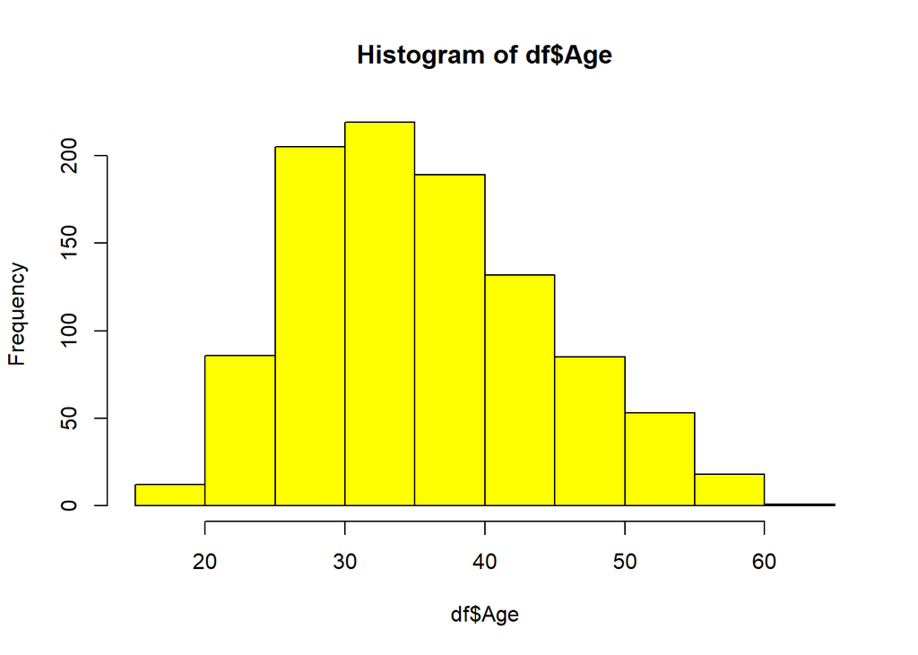

```r
# visualizing the age distribution using histogram
hist(df$Age, col = c('yellow'))
```

```r
# there is a higher tendency that a person aged between 30 and 35 years of age accessed her ads.
```

- The age distribution is right skewed
- The respondents on the website are mostly 25-40 years old
- The mean age is 36
- The median age is 35

```r
# visualizing the age distribution using bar graph
# fetching the age column
age <- df$Age

# applying the table() function the compute the frequency of the Age column
age_frequency <- table(age)
age_frequency
```

```
## age
## 19 20 21 22 23 24 25 26 27 28 29 30 31 32 33 34 35 36 37 38 39 40 41 42 43 44
##  6  6  6 13 19 21 27 37 33 48 48 39 60 38 43 39 39 50 36 37 30 36 32 26 23 21
## 45 46 47 48 49 50 51 52 53 54 55 56 57 58 59 60 61
## 30 18 13 16 18 20 12 15 10  9  7  2  6  4  2  4  1
```

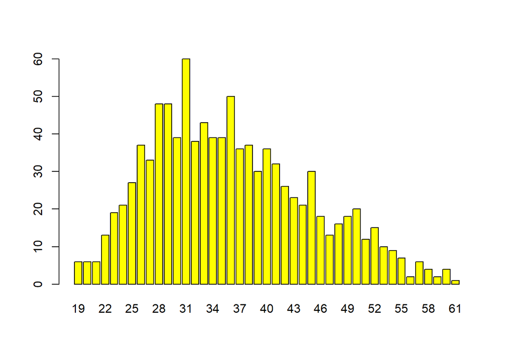

```r
barplot(age_frequency, col = 'yellow')
```

```r
# most people accessing her ads where aged 31 years
```

# Area_income

```r
#income
#central tendancy
mean(df$`Area Income`)
```

```
## [1] 55000
```

```r
median(df$`Area Income`)
```

```
## [1] 57012.3
```

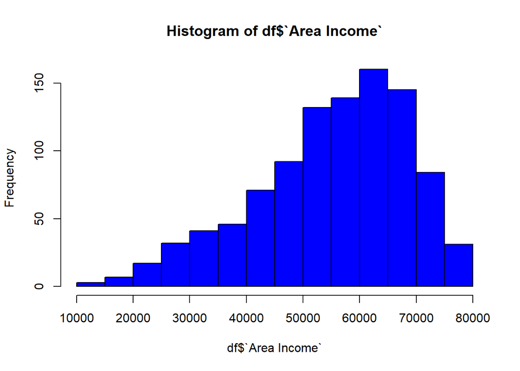

```r
# visualizing the area_income distribution using histogram
hist(df$`Area Income`, col = 'blue')
```

```r
#people leaving within an area_income between 60,000 and 65,000 had access on her ads the most
```

- The income distribution is Left skewed
- The respondents on the website mostly earn between 55,000 to 70,000
- The mean income is 55,000
- The median income is 57,012

# Daily_Internet_Usage

```r
#this column represents the amount of data that the user consumes in a day
# measures of central tendency
mean(df$`Daily Internet Usage`)
```

```
## [1] 180.0001
```

```r
median(df$`Daily Internet Usage`)
```

```
## [1] 183.13
```

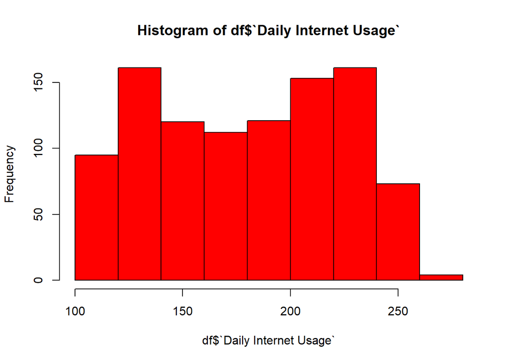

```r
# visualizing the daily_internet_usage distribution using histogram
hist(df$`Daily Internet Usage`, col = 'red')
```

- The mean data usage is 180 units - The median data usage is 183.13 units

# Ad_Topic_Line

```r
ad_topic_line <- df$`Ad Topic Line`

levels(unique(ad_topic_line))
```

```r
#factor(unique(ad_topic_line))
```

- All the values are unique in this column thus we would drop it when modelling since it does not provide any additional meaningful information

#City

```r
# City where the user is located
# measure of central tendency
length(levels(df$City))
```

```
## [1] 0
```

```r
#mode (the modal cities in the dataset)
city_x <- df$City

#sort(city_x). This code gives an ordered list of all the elements in the cities column
names(table(city_x))[table(city_x)==max(table(city_x))]
```

```
## [1] "Lisamouth"    "Williamsport"
```

- The most popular cities in the dataset are: “Lisamouth” “Williamsport”

#Gender

```r
# gender of the user
# fetching the Male column
gender <- df$Male

# applying the table() function to compute the frequency of the Male column
gender_frequency <- table(gender)
gender_frequency
```

```
## gender
##   0   1
## 519 481
```

```r
# 1 represented the males and 0 represented the females
```

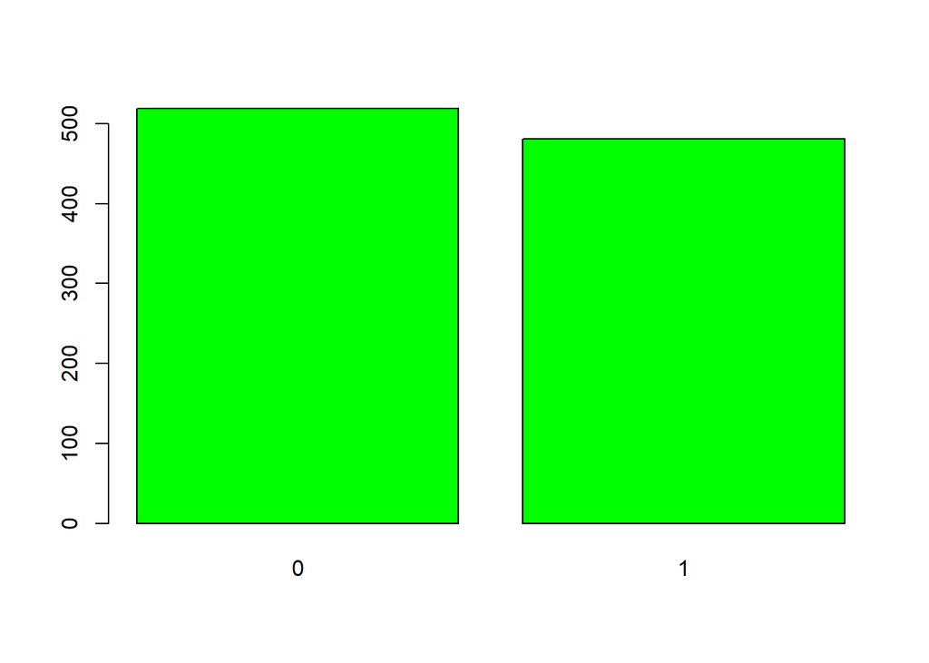

```r
# visualizing the Gender distribution using bar graph
barplot(gender_frequency, col = 'green')
```

```r
# most of the people who accessed her ads were females
```

#Daily_Time_Spent_on_Site

```r
# This column represents the amount of time that the user spends on the website
# measures of central of tendency
mean(df$`Daily Time Spent on Site`)
```

```
## [1] 65.0002
```

```r
median(df$`Daily Time Spent on Site`)
```

```
## [1] 68.215
```

```r
#mode
x <- df$`Daily Time Spent on Site`

#sort(x)
names(table(x))[table(x)==max(table(x))]
```

```
## [1] "62.26" "75.55" "77.05" "78.76" "84.53"
```

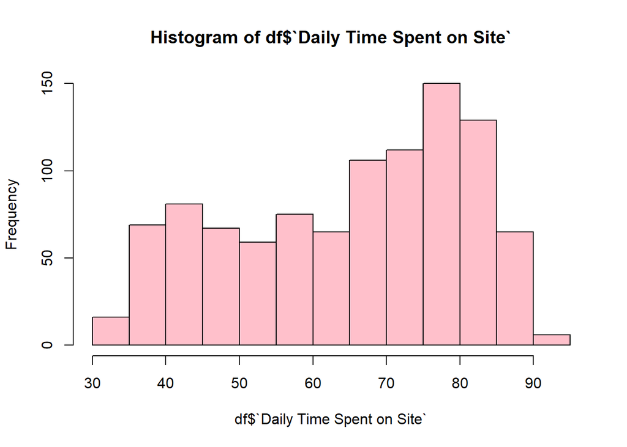

```r
# visualizing the daily time spent on site using histogram
hist(df$`Daily Time Spent on Site`, col = 'pink')
```

```r
# majority of the people spent between 75 and 80 hrs on her site.
```

- The users spend an average of 65.002 minutes on the website
- The modal time is “62.26” “75.55” “77.05” “78.76” “84.53”
- The median time is 68.215
- The distribution above is left-skewed

# Country

```r
# Country where the user belongs
# measures of central tendency
country_x <- df$Country

# levels(country_x) code gives the names of the countries
length(levels(country_x))
```

```
## [1] 0
```

```r
#the modal countries in the dataset
names(table(country_x))[table(country_x)==max(table(country_x))]
```

```
## [1] "Czech Republic" "France"
```

- The most popular countries are: “Czech Republic” “France”

# clicked on ads

```r
# Visualizing the number of people who clicked on the ads using bar graph
# fetching the clicked on add column
clicked_on_ad <- df$`Clicked on Ad`

#applying the table() function to compute the frequency of clicked on ad column
clicked_on_ad_frequency <- table(clicked_on_ad)
clicked_on_ad_frequency
```

```
## clicked_on_ad
##   0   1
## 500 500
```

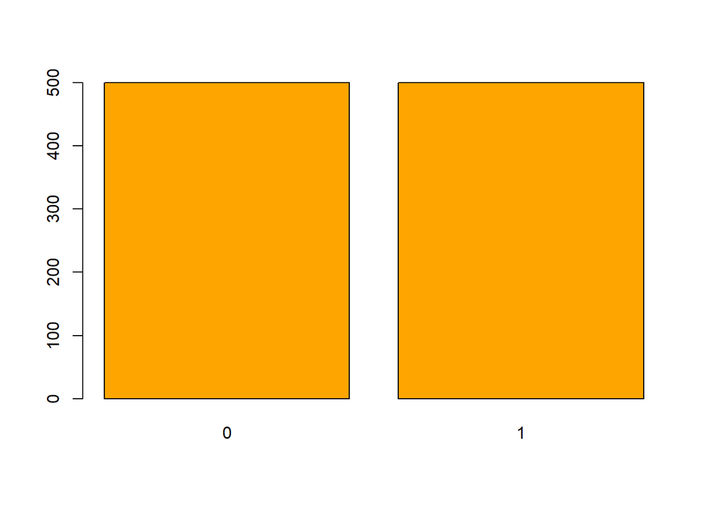

```r
barplot(clicked_on_ad_frequency, col = 'orange')
```

```r
# half the number of people who had an access to her ads clicked on it.
```

## BIVARIATE ANALYSIS

```r
# Checking for covariance between area income and daily internet usage variables
#assigning the area income column to area_income variable
area_income <- df$`Area Income`

#assigning the daily internet usage column to daily_internet_usage
daily_internet_usage <- df$`Daily Internet Usage`

cov(area_income, daily_internet_usage)
```

```
## [1] 198762.5
```

- There is a positive linear relationship between the two variables

```r
# Checking for correlation coefficient between area income and daily internet usage variables
cor(area_income, daily_internet_usage)
```

```
## [1] 0.3374955
```

-This indicates that there is a weak linear relationship between the two variables because their correlation coefficient is close to zero

# Scatterplots of a few pairs of variables

##Time spent on the site vs age of the user

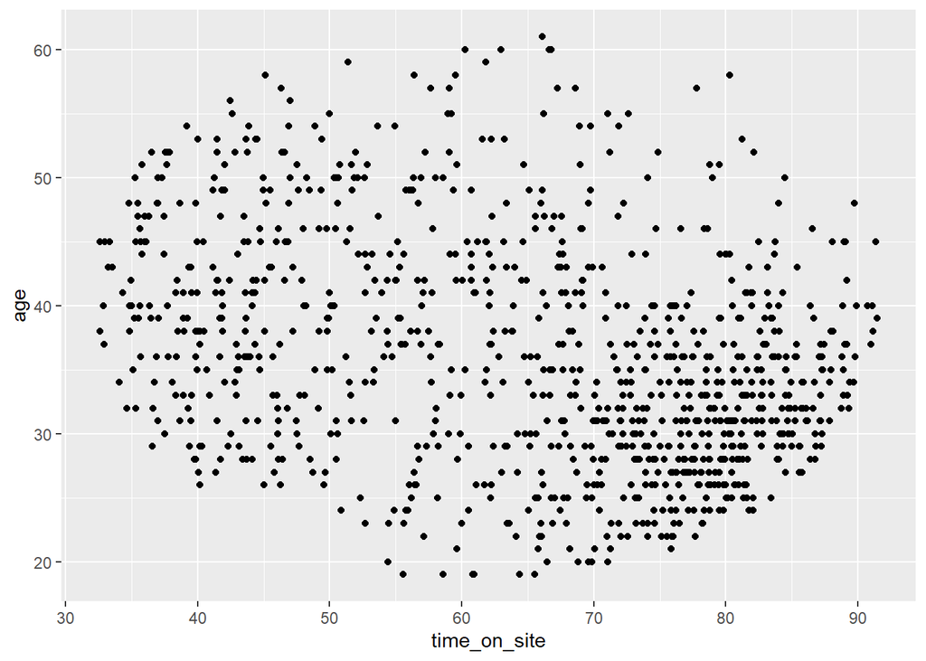

```r
#libraries\
library(ggplot2)

#creating the data
time_on_site <- df$`Daily Time Spent on Site`
age <- df$Age
data <- data.frame(time_on_site,age)

#plot
ggplot(data, aes(x=time_on_site, y=age)) + geom_point()
```

## Age of the user vs Daily internet usage

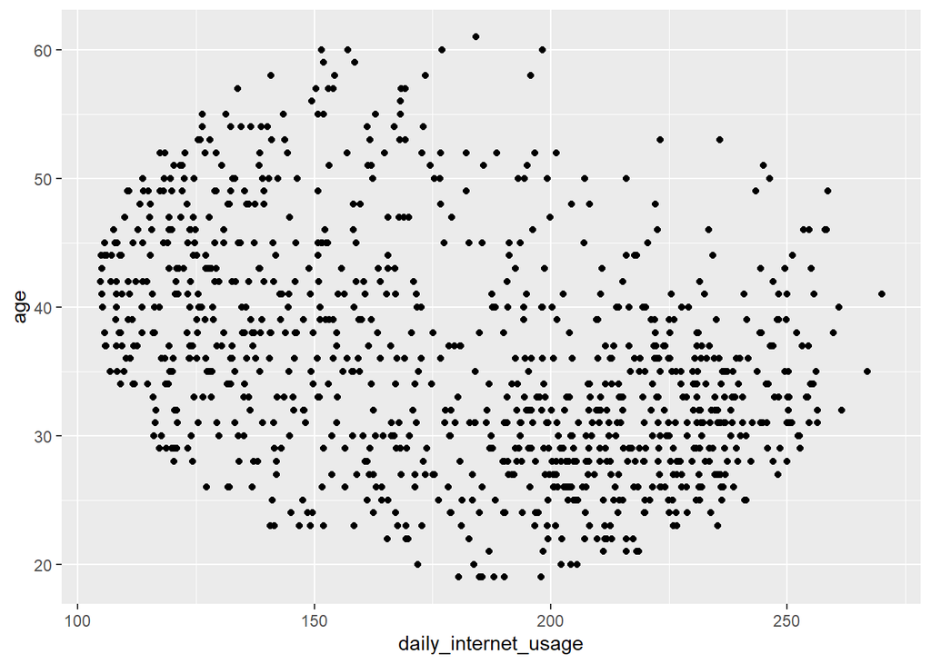

```r
data1 <- data.frame(daily_internet_usage,age)

#plot
ggplot(data1, aes(x=daily_internet_usage,y=age)) + geom_point()
```

## Time spent on the site vs Area income

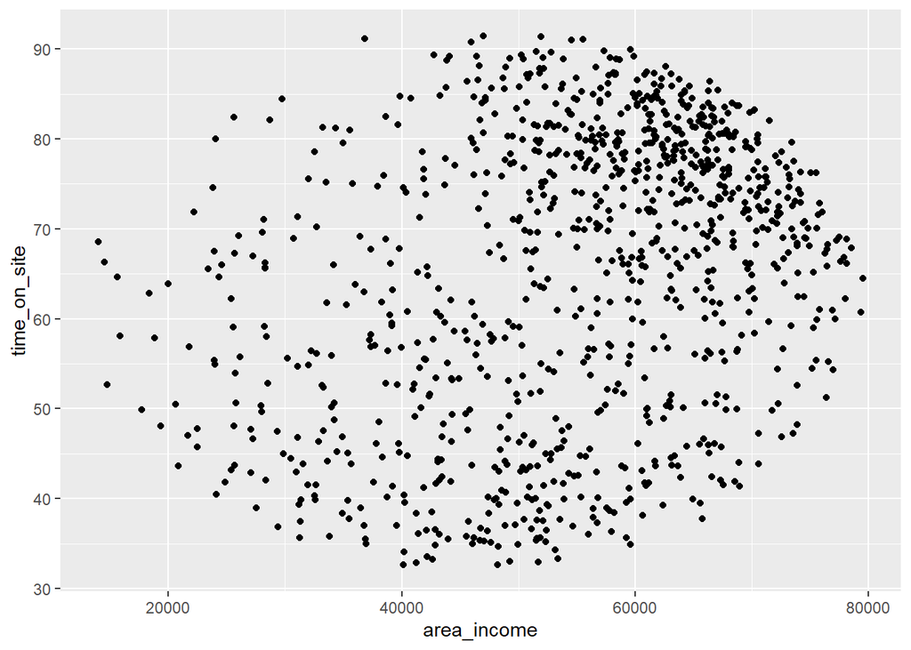

```r
data2 <- data.frame(area_income,time_on_site)

#plot
ggplot(data2, aes(x=area_income,y=time_on_site)) + geom_point()
```

- Positive non-linear correlation

## Time spent on the site vs Daily internet usage

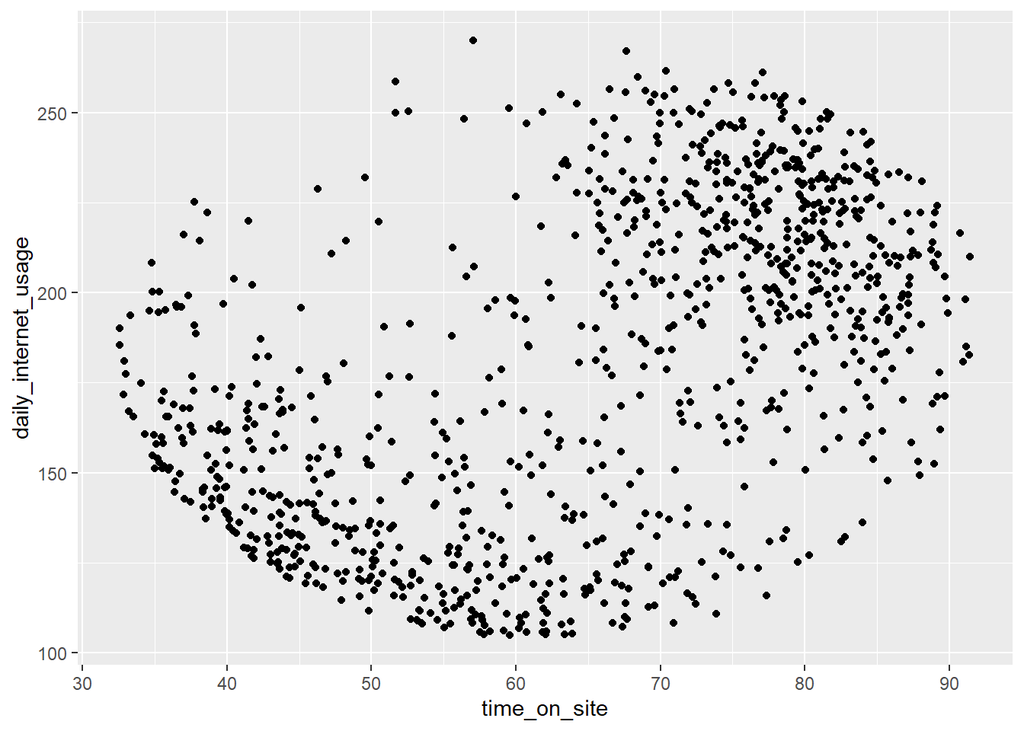

```r
data3 <- data.frame(time_on_site,daily_internet_usage)

#plot
ggplot(data3, aes(x=time_on_site, y=daily_internet_usage)) + geom_point()
```

# Gender Vs Clicked on ads

```r
library(tidyverse)

# Male respondents who clicked on the ads
dim(df %>% filter(Male == 1, `Clicked on Ad` == 1))
```

```
## [1] 231  10
```

```r
# Male respondents who did not on the ads
dim(df %>% filter(Male == 1, `Clicked on Ad` == 0))
```

```
## [1] 250  10
```

```r
# Female respondents who clicked on the ads
dim(df %>% filter(Male == 0, `Clicked on Ad` == 1))
```

```
## [1] 269  10
```

```r
# Female respondents who did not click on the ads
dim(df %>% filter(Male == 0, `Clicked on Ad` == 0))
```

```
## [1] 250  10
```

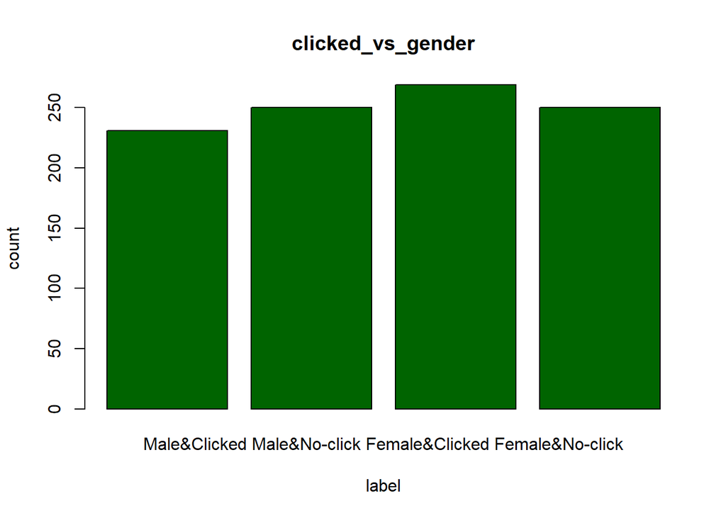

```r
clicked_vs_gender <- c(231, 250, 269, 250)

# bargraph with added parameters
barplot(clicked_vs_gender, main = 'clicked_vs_gender', xlab = 'label',ylab = 'count', names.arg = c('Male&Clicked Male&No-click Female&Clicked Female&No-click'), col = 'darkgreen', horiz = FALSE)
```

# CONCLUSION